# Week 03: Ensemble Learning & Random Forests

Ziyuan Huang

Last Updated: April 02, 2026

```r
library(seedhash)
gen <- SeedHashGenerator$new("ANLY530-Week03-RandomForest")
MASTER_SEED <- gen$generate_seeds(1)
set.seed(MASTER_SEED)
```

**Random Seed Source:** `seedhash` package — input string: `"ANLY530-Week03-RandomForest"` → seed: `694647825`

# Introduction

Last week, we learned that a single Decision Tree — while intuitive — is **unstable**: a small change in the data can produce a completely different tree. This week, we fix that by combining many trees into a **forest**.

> *“If you aggregate the predictions of a group of predictors (such as classifiers or regressors), you will often get better predictions than with the best individual predictor. A group of predictors is called an **ensemble**; thus, this technique is called Ensemble Learning, and an Ensemble Learning algorithm is called an Ensemble method.”* — A. Géron **[1]**

> *“Random forests are a modification of bagged decision trees that build a large collection of de-correlated trees to further improve predictive performance.”* — B. C. Boehmke & B. M. Greenwell **[2]**

This is the **wisdom of the crowd** in action. Thousands of people independently guessing the weight of an ox will, on average, be surprisingly accurate — more accurate than any single expert. The same principle makes ensembles so powerful.

**Learning Objectives:**

By the end of this tutorial, you will be able to:

1. Explain the intuition behind **ensemble learning** and why diversity matters.
2. Distinguish **hard voting** from **soft voting** classifiers.
3. Implement **Bagging** and understand Out-of-Bag (OOB) evaluation.
4. Build, tune, and interpret a **Random Forest** in R.
5. Explain how **feature importance** is computed in a Random Forest.
6. Understand **Extra-Trees** and when to prefer them over Random Forests.
7. Compare Random Forests to **Boosting** (AdaBoost, Gradient Boosting).
8. Apply Random Forests to both **classification** and **regression** tasks.

## Required Packages

```r
if (!require("pacman")) install.packages("pacman")
pacman::p_load(
  tidyverse,
  randomForest,
  rpart,
  rpart.plot,
  gridExtra,
  gbm,
  scales
)
```

# Part 1: The Wisdom of the Crowd — Voting Classifiers

## 1.1 Why Ensembles Work

Suppose you flip a slightly biased coin that lands heads 51% of the time. Flip it 1,000 times — you’ll get roughly 510 heads (majority heads). Flip it 10,000 times — the probability of a majority of heads climbs to over 97%. This is the **Law of Large Numbers** in action.

The same logic applies to classifiers. If each classifier is correct 51% of the time (barely better than random), but each makes **different** mistakes, combining 1,000 of them can yield 75% accuracy!

The key requirement: **classifiers must be as independent as possible** (i.e., make different types of errors).

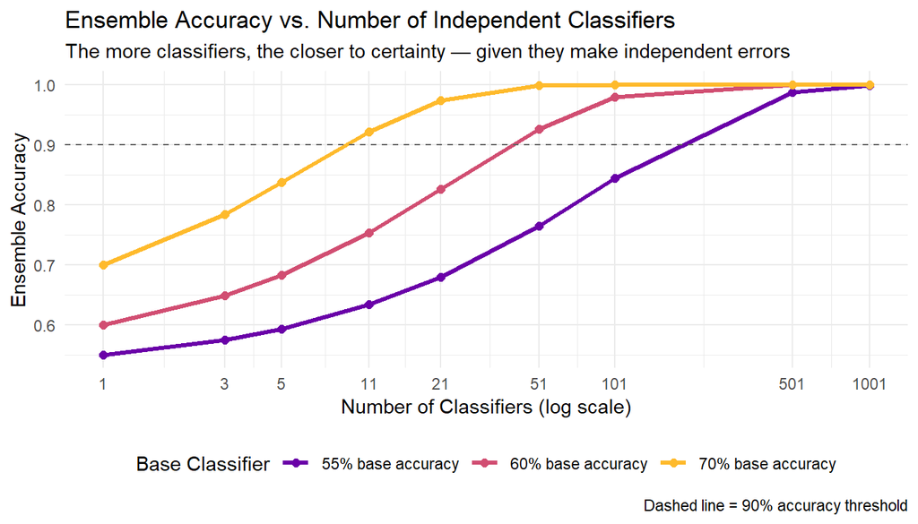

```r
simulate_ensemble_accuracy <- function(n_classifiers, base_acc) {
  # P(majority correct) for n independent classifiers each with P(correct) = base_acc
  # Using binomial distribution: P(k > n/2 correct out of n)
  k_needed <- floor(n_classifiers / 2) + 1
  sum(dbinom(k_needed:n_classifiers, n_classifiers, base_acc))
}

classifiers <- c(1, 3, 5, 11, 21, 51, 101, 501, 1001)
results <- data.frame(
  n = classifiers,
  acc_55 = sapply(classifiers, simulate_ensemble_accuracy, base_acc = 0.55),
  acc_60 = sapply(classifiers, simulate_ensemble_accuracy, base_acc = 0.60),
  acc_70 = sapply(classifiers, simulate_ensemble_accuracy, base_acc = 0.70)
) %>%
  pivot_longer(-n, names_to = "base", values_to = "ensemble_acc") %>%
  mutate(base = recode(base,
    acc_55 = "55% base accuracy",
    acc_60 = "60% base accuracy",
    acc_70 = "70% base accuracy"
  ))

ggplot(results, aes(x = n, y = ensemble_acc, color = base)) +
  geom_line(linewidth = 1.2) +
  geom_point(size = 2) +
  geom_hline(yintercept = 0.9, linetype = "dashed", color = "grey40") +
  scale_x_log10(breaks = classifiers, labels = as.character(classifiers)) +
  scale_color_viridis_d(option = "plasma", begin = 0.2, end = 0.85) +
  labs(
    title = "Ensemble Accuracy vs. Number of Independent Classifiers",
    subtitle = "The more classifiers, the closer to certainty — given they make independent errors",
    x = "Number of Classifiers (log scale)",
    y = "Ensemble Accuracy",
    color = "Base Classifier",
    caption = "Dashed line = 90% accuracy threshold"
  ) +
  theme_minimal() +
  theme(legend.position = "bottom")
```

## 1.2 Hard Voting vs. Soft Voting

There are two ways to aggregate predictions in a voting classifier:

| Method | Mechanism | Requires |
| --- | --- | --- |
| **Hard Voting** | Take the most frequent predicted class (majority vote) | Only class labels |
| **Soft Voting** | Average predicted **probabilities**, pick highest | `predict_proba()` for each model |

Soft voting often beats hard voting because it gives **more weight to high-confidence predictions**. A classifier that says “99% Class A” counts for more than one that says “51% Class A”.

Let’s simulate this on the Iris dataset using three diverse base learners:

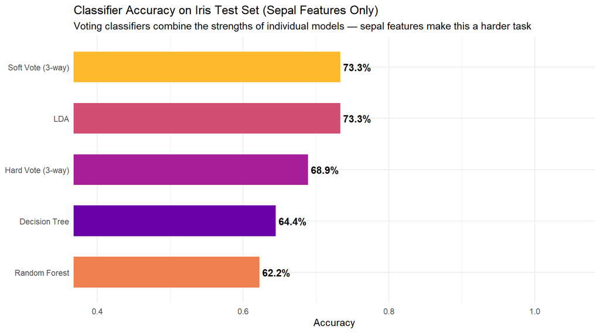

```r
data(iris)

# Use sepal features only — deliberately harder (versicolor/virginica overlap here)
# Petal features are too perfectly separable → all classifiers agree on everything → no
# visible difference between individual and ensemble, which defeats the tutorial's point.
iris_vote <- iris[, c("Sepal.Length", "Sepal.Width", "Species")]

# Train/test split (70/30)
set.seed(MASTER_SEED)
idx <- sample(1:nrow(iris_vote), size = floor(0.7 * nrow(iris_vote)))
train <- iris_vote[idx, ]
test  <- iris_vote[-idx, ]

# --- Three diverse base learners ---
# 1. Shallow Decision Tree (high bias, low variance)
tree_model <- rpart(Species ~ ., data = train, control = rpart.control(maxdepth = 2))

# 2. Random Forest (low bias, low variance — strong learner)
rf_model   <- randomForest(Species ~ ., data = train, ntree = 200)

# 3. LDA (Linear Discriminant Analysis) — linear boundary, different error pattern
lda_model  <- MASS::lda(Species ~ ., data = train)

# --- Individual predictions ---
pred_tree <- predict(tree_model, test, type = "class")
pred_rf   <- predict(rf_model,   test, type = "class")
pred_lda  <- predict(lda_model,  test)$class

# --- Hard Voting: true majority vote across 3 classifiers ---
hard_vote_mat <- data.frame(
  tree = as.character(pred_tree),
  rf   = as.character(pred_rf),
  lda  = as.character(pred_lda)
)
hard_vote <- apply(hard_vote_mat, 1, function(row) names(which.max(table(row))))
hard_vote <- factor(hard_vote, levels = levels(test$Species))

# --- Soft Voting: average class probabilities across 3 classifiers ---
prob_tree <- predict(tree_model, test, type = "prob")
prob_rf   <- predict(rf_model,   test, type = "prob")
prob_lda  <- predict(lda_model,  test)$posterior

avg_prob  <- (prob_tree + prob_rf + prob_lda) / 3
soft_vote <- factor(colnames(avg_prob)[apply(avg_prob, 1, which.max)],
                    levels = levels(test$Species))

# --- Accuracy ---
acc_tree <- mean(pred_tree == test$Species)
acc_rf   <- mean(pred_rf   == test$Species)
acc_lda  <- mean(pred_lda  == test$Species)
acc_hard <- mean(hard_vote == test$Species)
acc_soft <- mean(soft_vote == test$Species)

acc_df <- data.frame(
  Model    = c("Decision Tree", "LDA", "Random Forest", "Hard Vote (3-way)", "Soft Vote (3-way)"),
  Accuracy = c(acc_tree, acc_lda, acc_rf, acc_hard, acc_soft)
)

ggplot(acc_df, aes(x = reorder(Model, Accuracy), y = Accuracy, fill = Model)) +
  geom_col(width = 0.6) +
  geom_text(aes(label = scales::percent(Accuracy, accuracy = 0.1)),
            hjust = -0.1, fontface = "bold") +
  coord_flip(ylim = c(0.4, 1.05)) +
  scale_fill_viridis_d(option = "plasma", begin = 0.2, end = 0.85) +
  labs(
    title = "Classifier Accuracy on Iris Test Set (Sepal Features Only)",
    subtitle = "Voting classifiers combine the strengths of individual models — sepal features make this a harder task",
    x = NULL, y = "Accuracy"
  ) +
  theme_minimal() +
  theme(legend.position = "none")
```

# Part 2: Bagging — Same Algorithm, Different Data

## 2.1 What Is Bagging?

Instead of training different algorithms on the same data, **bagging** (Bootstrap AGGregating) trains the **same algorithm** on different random **bootstrapped subsets** of the training data.

- **Bagging**: sample **with replacement** (bootstrap). Each predictor may see ~63% of unique training instances.
- **Pasting**: sample **without replacement**.

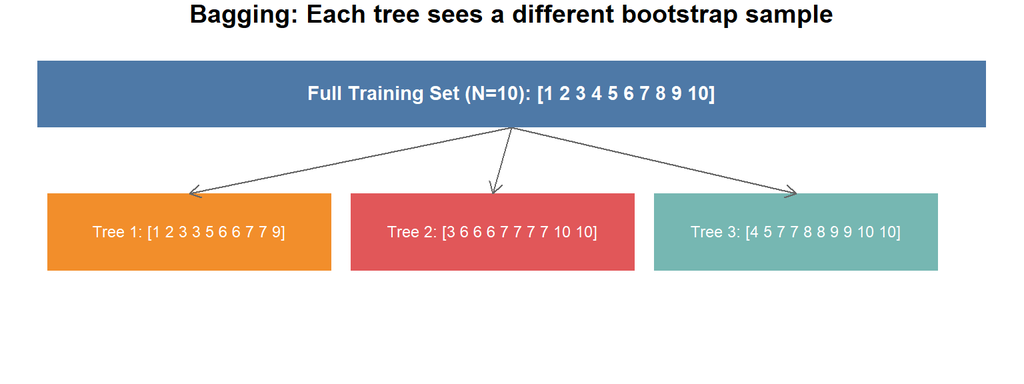

## 2.2 Why ~63%? The Out-of-Bag Math

When bootstrapping a dataset of size $m$ with replacement, the probability that any single instance is **not** selected in one draw is $\frac{m-1}{m}$. After $m$ draws:

$$P(\text{not selected in any draw}) =
\left(1 - \frac{1}{m}\right)^m \xrightarrow{m \to \infty} e^{-1} \approx
0.368$$

So each bootstrap sample leaves out about **37% of instances** — these are the **Out-of-Bag (OOB)** instances.

### Visualizing the Bootstrap: Which Instances Go Where?

The heatmap below shows a small example (20 training instances, 10 trees). Each cell is colored **blue** if instance $i$ is **in the bootstrap sample** for tree $j$, and **orange** if it is **OOB** (held-out for that tree).

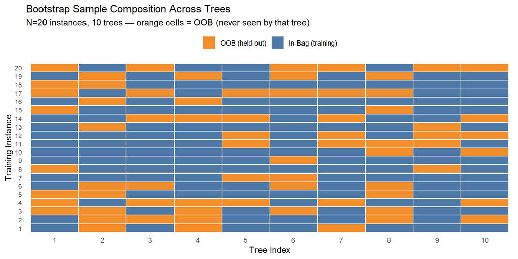

```r
set.seed(MASTER_SEED)
n_inst  <- 20   # training instances
n_tr    <- 10   # trees to show

# Build in-bag (1) vs OOB (0) matrix
inbag_mat <- matrix(0L, nrow = n_inst, ncol = n_tr)
for (j in 1:n_tr) {
  selected <- sample(1:n_inst, n_inst, replace = TRUE)
  inbag_mat[unique(selected), j] <- 1L
}

# Compute each instance's OOB count
oob_counts <- rowSums(inbag_mat == 0)

inbag_df <- as.data.frame(inbag_mat) %>%
  mutate(Instance = 1:n_inst) %>%
  pivot_longer(-Instance, names_to = "Tree", values_to = "Status") %>%
  mutate(
    Tree   = factor(as.integer(gsub("V", "", Tree))),
    Status = factor(Status, levels = c(0, 1), labels = c("OOB (held-out)", "In-Bag (training)"))
  )

ggplot(inbag_df, aes(x = Tree, y = factor(Instance), fill = Status)) +
  geom_tile(color = "white", linewidth = 0.5) +
  scale_fill_manual(values = c("OOB (held-out)" = "#F28E2B", "In-Bag (training)" = "#4E79A7")) +
  labs(
    title = "Bootstrap Sample Composition Across Trees",
    subtitle = sprintf("N=%d instances, %d trees — orange cells = OOB (never seen by that tree)",
                       n_inst, n_tr),
    x = "Tree Index", y = "Training Instance",
    fill = NULL
  ) +
  theme_minimal() +
  theme(legend.position = "top",
        axis.text.y = element_text(size = 8),
        panel.grid = element_blank())
```

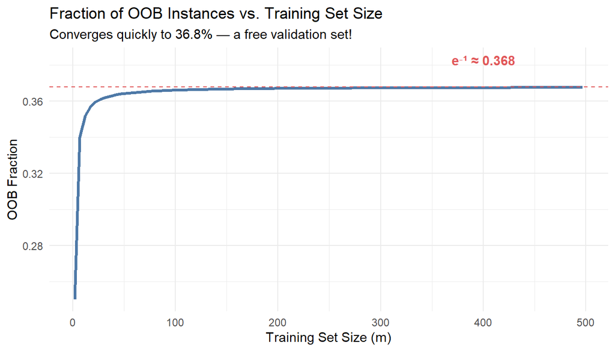

```r
m_values <- seq(2, 500, by = 5)
oob_frac  <- (1 - 1 / m_values)^m_values

ggplot(data.frame(m = m_values, oob = oob_frac), aes(x = m, y = oob)) +
  geom_line(color = "#4E79A7", linewidth = 1.2) +
  geom_hline(yintercept = exp(-1), linetype = "dashed", color = "#E15759") +
  annotate("text", x = 400, y = exp(-1) + 0.015,
           label = sprintf("e⁻¹ ≈ %.3f", exp(-1)),
           color = "#E15759", fontface = "bold") +
  labs(
    title = "Fraction of OOB Instances vs. Training Set Size",
    subtitle = "Converges quickly to 36.8% — a free validation set!",
    x = "Training Set Size (m)", y = "OOB Fraction"
  ) +
  theme_minimal()
```

## 2.3 Manual Bagging in R

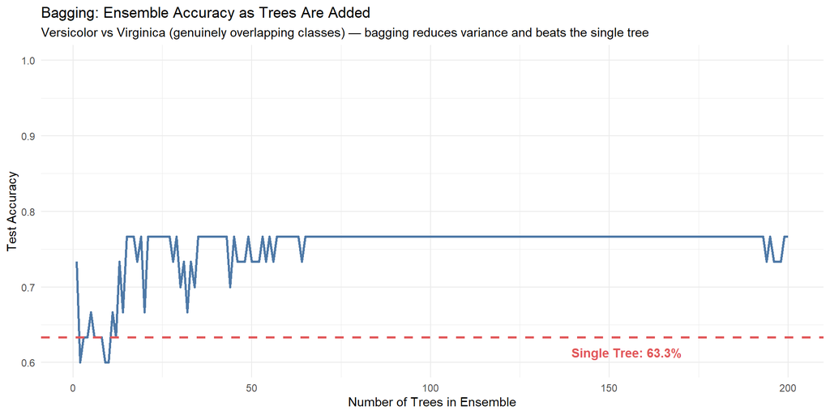

```r
set.seed(MASTER_SEED)
n_trees <- 200

# Binary classification: versicolor vs virginica — deliberately hard (real sepal overlap)
# Setosa vs other is nearly perfectly separable → all bootstrap trees identical → flat line
iris_bin <- iris %>%
  filter(Species %in% c("versicolor", "virginica")) %>%
  mutate(label = droplevels(Species)) %>%
  select(Sepal.Length, Sepal.Width, label)

idx_tr    <- sample(1:nrow(iris_bin), 70)
train_bin <- iris_bin[idx_tr, ]
test_bin  <- iris_bin[-idx_tr, ]

# Train bagged ensemble manually
bag_preds <- matrix(NA, nrow = nrow(test_bin), ncol = n_trees)

for (i in 1:n_trees) {
  boot_idx  <- sample(1:nrow(train_bin), nrow(train_bin), replace = TRUE)
  boot_data <- train_bin[boot_idx, ]
  tree_i    <- rpart(label ~ ., data = boot_data, control = rpart.control(maxdepth = 4))
  bag_preds[, i] <- as.character(predict(tree_i, test_bin, type = "class"))
}

# Hard voting: majority class at each k trees
ensemble_acc <- sapply(1:n_trees, function(k) {
  votes <- bag_preds[, 1:k, drop = FALSE]
  final <- apply(votes, 1, function(row) {
    tbl <- table(row)
    names(which.max(tbl))
  })
  mean(final == as.character(test_bin$label))
})

single_tree <- rpart(label ~ ., data = train_bin, control = rpart.control(maxdepth = 4))
single_acc  <- mean(predict(single_tree, test_bin, type = "class") == test_bin$label)

ggplot(data.frame(n = 1:n_trees, acc = ensemble_acc), aes(x = n, y = acc)) +
  geom_line(color = "#4E79A7", linewidth = 1) +
  geom_hline(yintercept = single_acc, linetype = "dashed", color = "#E15759", linewidth = 1) +
  annotate("text", x = 155, y = single_acc - 0.02,
           label = sprintf("Single Tree: %.1f%%", single_acc * 100),
           color = "#E15759", fontface = "bold") +
  labs(
    title = "Bagging: Ensemble Accuracy as Trees Are Added",
    subtitle = "Versicolor vs Virginica (genuinely overlapping classes) — bagging reduces variance and beats the single tree",
    x = "Number of Trees in Ensemble", y = "Test Accuracy"
  ) +
  coord_cartesian(ylim = c(0.6, 1.0)) +
  theme_minimal()
```

# Part 3: Random Forests — Decorrelated Trees

## 3.1 From Bagging to Random Forests

Bagging reduces **variance** (instability) by averaging many trees. But there’s still a problem: if one or two features are very strong predictors, most trees will split on them first — making the trees **correlated** with each other. Correlated trees don’t reduce variance as effectively.

**Random Forests** solve this with one simple trick:

> At each split, only a **random subset of features** (typically $\sqrt{p}$ for classification, $p/3$ for regression) is considered as split candidates.

This **decorrelates** the trees — even if Feature A is the best predictor overall, it won’t dominate every tree, because sometimes it won’t even be in the candidate set!

### Visualizing Tree Diversity: Approximating Six Trees from the Forest

R’s `randomForest` package does not support direct plotting of its internal trees. Below we approximate the visualization by training `rpart` trees on the **same bootstrap samples** that the RF used. With only 2 features (petal only) and `mtry = 1`, different bootstrap samples naturally produce different tree structures — illustrating the diversity that makes ensembles powerful.

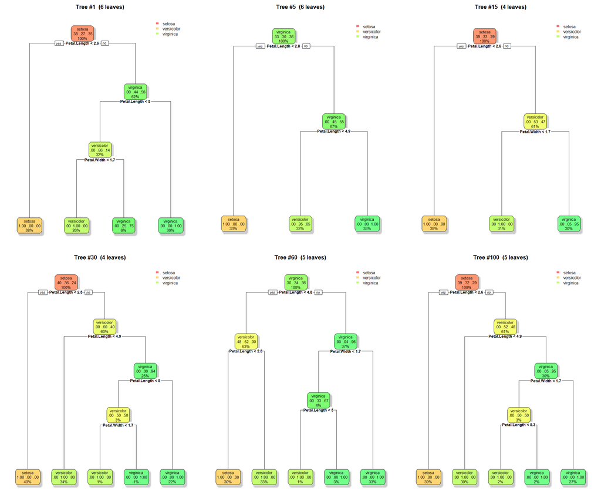

```r
set.seed(MASTER_SEED)
# Build a small RF on the 2-feature iris (petal only) for easy visualization
iris_2feat <- iris[, c("Petal.Length", "Petal.Width", "Species")]
train_2f   <- iris_2feat[train_idx, ]

rf_small <- randomForest(
  Species ~ .,
  data       = train_2f,
  ntree      = 100,
  mtry       = 1,       # only 1 feature per split → maximum diversity
  importance = FALSE,
  keep.inbag = TRUE
)

# Extract and plot 6 individual trees
# Since rpart can't enforce mtry, we randomly select 1 feature per bootstrap sample
# to approximate the RF's mtry=1 constraint for visualization purposes
par(mfrow = c(2, 3), mar = c(1, 1, 2, 1))
all_feats <- c("Petal.Length", "Petal.Width")
for (tree_id in c(1, 5, 15, 30, 60, 100)) {
  tree_df <- getTree(rf_small, k = tree_id, labelVar = TRUE)
  n_leaves <- sum(tree_df$status == -1)

  boot_obs <- which(rf_small$inbag[, tree_id] > 0)
  if (length(unique(train_2f$Species[boot_obs])) > 1 && length(boot_obs) > 5) {
    # With only 2 features and mtry=1, each split considers only 1 random feature
    # rpart with the full bootstrap sample approximates the structure
    t_i <- rpart(Species ~ .,
                 data    = train_2f[boot_obs, ],
                 control = rpart.control(maxdepth = 4, minsplit = 2, cp = 0))
    rpart.plot(t_i,
               main        = sprintf("Tree #%d  (%d leaves)", tree_id, n_leaves),
               type        = 2,
               extra       = 104,
               box.palette = "RdYlGn",
               shadow.col  = "grey80",
               cex         = 0.7)
  }
}
```

```r
par(mfrow = c(1, 1))
```

### Tree-to-Tree Correlation: Bagging vs. Random Forests

The power of RF over plain Bagging comes from **reducing inter-tree correlation**. When trees are correlated, the variance of the average is:

$$\text{Var}\!\left(\bar{T}\right) = \rho
\sigma^2 + \frac{1-\rho}{B}\sigma^2$$

As $B \to \infty$, the second term vanishes but $\rho \sigma^2$ remains. **Lower correlation → lower ensemble variance.**

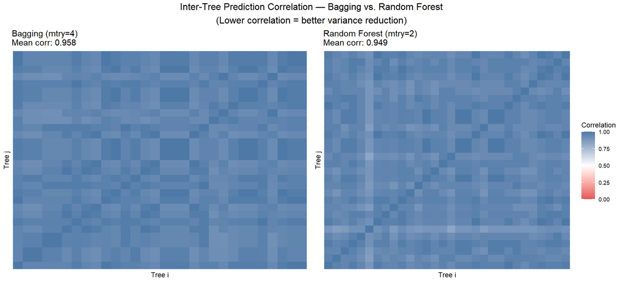

```r
set.seed(MASTER_SEED)
n_trees_corr <- 30

# Bagging: all 4 features at each split (mtry = 4)
rf_bag <- randomForest(Species ~ ., data = iris_train, ntree = n_trees_corr,
                       mtry = ncol(iris_train) - 1, importance = FALSE)

# RF: sqrt(4) = 2 features per split
rf_rf  <- randomForest(Species ~ ., data = iris_train, ntree = n_trees_corr,
                       mtry = 2, importance = FALSE)

# Individual tree predictions: randomForest returns a CHARACTER matrix of class names.
# as.numeric("setosa") is NA — must map to 1/2/3 first or cor() is all NA (grey heatmap).
get_tree_preds <- function(rf_obj, newdata) {
  p <- predict(rf_obj, newdata, predict.all = TRUE)
  ind <- p$individual
  lv  <- levels(rf_obj$y)
  matrix(match(as.vector(ind), lv), nrow = nrow(ind), ncol = ncol(ind))
}

bag_preds_mat <- get_tree_preds(rf_bag, iris_test)
rf_preds_mat  <- get_tree_preds(rf_rf,  iris_test)

# Pairwise Pearson correlation between trees' prediction vectors (numeric class codes)
compute_pair_corr <- function(pred_mat) {
  n <- ncol(pred_mat)
  cors <- matrix(NA_real_, n, n)
  for (i in seq_len(n)) for (j in seq_len(n)) {
    cors[i, j] <- cor(pred_mat[, i], pred_mat[, j], use = "complete.obs")
  }
  diag(cors) <- 1
  cors
}

bag_corr <- compute_pair_corr(bag_preds_mat)
rf_corr  <- compute_pair_corr(rf_preds_mat)

corr_to_df <- function(m, label) {
  as.data.frame(m) %>%
    mutate(Tree_i = 1:nrow(m)) %>%
    pivot_longer(-Tree_i, names_to = "Tree_j_str", values_to = "Correlation") %>%
    mutate(Tree_j = as.integer(gsub("V", "", Tree_j_str)), Model = label)
}

corr_df <- bind_rows(
  corr_to_df(bag_corr, sprintf("Bagging (mtry=%d, all features)", ncol(iris_train)-1)),
  corr_to_df(rf_corr,  "Random Forest (mtry=2)")
)

p_bag <- ggplot(filter(corr_df, Model == sprintf("Bagging (mtry=%d, all features)", ncol(iris_train)-1)),
       aes(x = factor(Tree_i), y = factor(Tree_j), fill = Correlation)) +
  geom_tile() +
  scale_fill_gradient2(low = "#E15759", mid = "white", high = "#4E79A7",
                       midpoint = 0.5, limits = c(0, 1)) +
  labs(title = sprintf("Bagging (mtry=4)\nMean corr: %.3f",
                       mean(bag_corr[upper.tri(bag_corr)], na.rm = TRUE)),
       x = "Tree i", y = "Tree j") +
  theme_minimal(base_size = 9) +
  theme(axis.text = element_blank(), legend.position = "none")

p_rf <- ggplot(filter(corr_df, Model == "Random Forest (mtry=2)"),
       aes(x = factor(Tree_i), y = factor(Tree_j), fill = Correlation)) +
  geom_tile() +
  scale_fill_gradient2(low = "#E15759", mid = "white", high = "#4E79A7",
                       midpoint = 0.5, limits = c(0, 1)) +
  labs(title = sprintf("Random Forest (mtry=2)\nMean corr: %.3f",
                       mean(rf_corr[upper.tri(rf_corr)], na.rm = TRUE)),
       x = "Tree i", y = "Tree j", fill = "Correlation") +
  theme_minimal(base_size = 9) +
  theme(axis.text = element_blank())

grid.arrange(p_bag, p_rf, ncol = 2,
  top = "Inter-Tree Prediction Correlation — Bagging vs. Random Forest\n(Lower correlation = better variance reduction)")
```

> **Note:** `randomForest::predict(..., predict.all = TRUE)$individual` is a **character** matrix of class names. Pearson correlation needs numeric codes — we map levels to 1, 2, 3 (a common shortcut for comparing agreement between classifiers).

[figure not shown]